# Step 1.0: Cohort Check

Mia Charifson

April 18, 2024

## Cohort check and variables

Goals of this document:

1. Check all inclusion and exclusion criteria closely in cohort provided by Chuan
2. Check the burn-in period for encounters and whether they re-engage within a year from entry into cohort (LTFU at baseline)
3. Derive loss to follow-up during the follow-up period & during COVID-19
4. Derive censoring due to menopause, death, receiving a hysterectomy or bilateral oophorectomy
5. Define healthcare utilization at baseline and during follow-up

```r
library(tidyverse)
library(ggplot2)
library(lubridate)
library(tableone)
library(arsenal)
library(readxl)
library(ggalluvial)
```

```r
pat_cohort <- read.csv('Data/Epic/table1_pat_cohort.csv')
enc_inpatient <- read.csv('Data/Epic/table2_enc_inpatient.csv')
enc_outpatient1 <- read.csv('Data/Epic/table2_enc_outpatient1.csv')
enc_outpatient2 <- read.csv('Data/Epic/table2_enc_outpatient2.csv')
enc_outpatient3 <- read.csv('Data/Epic/table2_enc_outpatient3.csv')
enc_telemedicine <- read.csv('Data/Epic/table2_enc_telemedicine.csv')
enc_ed <- read.csv('Data/Epic/table2_enc_ed.csv')
menopause <- read.csv('Data/Epic/table3_dx_menopause.csv')
surgery <- read.csv('Data/Epic/table4_surgery.csv')
uf_endo <- read.csv('Data/Epic/table3_dx_outcomes.csv')
uf_endo_filled_dates <-read.csv('Data/Epic/fill_missing_dx_dates.csv')
```

## 1.1. Check all relevant cohort inclusion and exclusion criteria

Entry year of cohort: August 1, 2016 - December 31, 2017

Inclusion criteria:

- Female
- Must have uterus and at least one ovary
- **Active patient with relevant care during entry year**
- **16 to 50 years old**
- **Alive at entry year of cohort**
- **Disease-free at entry year of cohort**
- **Regular relevant care in two years from entry into cohort**

Exclusion criteria:

- **Hx of hysterectomy or bilateral oophorectomy**
- Primary amenorrhea or sexual development disorder
- **No relevant care in the second year of cohort**

Bold criteria are ones I can check in this document. The other criteria were already applied by Chuan and cannot be retroactively checked based on the data but review of her code confirms their appropriate application.

```r
## reduce to first encounter
pat_unique <- pat_cohort %>%
  group_by(pat_id) %>%
  mutate(num_enc_index_yr = n()) %>%
  filter(enc_date == min(enc_date)) %>%
  distinct()

# paste together encounter ID and provider specialty if more than one on the date of index encounter
pat_unique <- pat_unique %>%
  group_by(pat_id) %>%
  summarise(index_enc_date = min(enc_date),
            death_date = paste0(unique(death_date), collapse = ', '),
            pat_living_stat_c = mean(pat_living_stat_c, na.rm=TRUE),
            age_20160801 = min(age_20160801, na.rm=TRUE),
            gender = paste0(unique(gender), collapse = ', '),
            pat_living_stat_c = mean(pat_living_stat_c, na.rm=TRUE),
            all_provider_specialty = paste0(unique(provider_specialty), collapse = ', '),
            all_pat_enc_csn_id = paste0(unique(pat_enc_csn_id), collapse = ', '),
            num_enc_index_yr = mean(num_enc_index_yr, na.rm=TRUE),
            .groups='drop') %>%
  mutate(index_enc_date = as.Date(index_enc_date))
```

### Dates of entry into cohort (index encounter)

```r
pat_unique %>%
  select(index_enc_date) %>%
  summary()
```

```
##  index_enc_date
##  Min.   :2016-08-01
##  1st Qu.:2016-10-20
##  Median :2017-02-14
##  Mean   :2017-03-08
##  3rd Qu.:2017-07-17
##  Max.   :2017-12-31
```

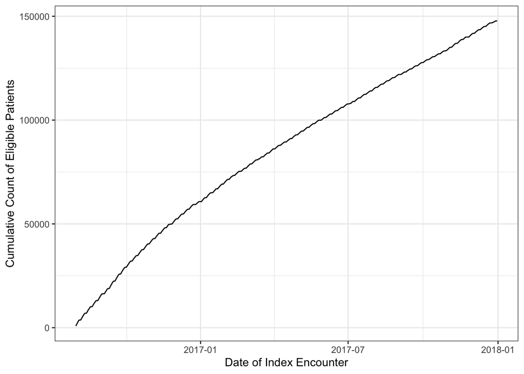

```r
pat_unique %>%
  group_by(index_enc_date) %>%
  summarise(count=n(), .groups='drop') %>%
  mutate(cumulative_count = cumsum(count)) %>%
  ggplot(data=., aes(x=index_enc_date, y=cumulative_count)) +
  geom_line() +
  ylab('Cumulative Count of Eligible Patients') +
  xlab('Date of Index Encounter') +
  theme_bw()
```

### Provider specialty at index encounter

```r
## need to separate provider specialties
general_care <- c('ACUTE CARE NURSE PRACTITIONER'
                  ,'ADULT HEALTH NURSE PRACTITIONER'
                  ,'GENERAL PRACTICE'
                  ,'MEDICINE, ADULT'
                  ,'MEDICINE, FAMILY MEDICINE'
                  ,'MEDICINE, INTERNAL MEDICINE'
                  ,'NURSE PRACTITIONER'
                  , "FAMILY NURSE PRACTITIONER"
                  , "PEDIATRIC NURSE PRACTITIONER"
                  , "PEDIATRICS, ADOLESCENT MEDICINE"
                  , "PEDIATRICS, GENERAL"
                  , "PHYSICIAN ASSISTANT"
                  , "PHYSICIAN ASSISTANT, MEDICAL"
                  , "REGISTERED NURSE")
obgyn_care <- c('OBSTETRICS & GYNECOLOGY'
                ,'OBSTETRICS & GYNECOLOGY NURSE PRACTITIONER'
                ,'OBSTETRICS GYNECOLOGY, GENERAL'
                , "WOMEN'S HEALTH NURSE PRACTITIONER")
gyn_care <- c('GYNECOLOGY, GENERAL'
              ,'GYNECOLOGY, REPRODUCTIVE ENDOCRINOLOGY'
              ,'GYNECOLOGY, URO-GYNECOLOGY'
              ,'UROLOGY, URO-GYNECOLOGY'
              , "GYNECOLOGY, GYNECOLOGIC ONCOLOGY")
endocrine_care <- c('MEDICINE, ENDOCRINOLOGY','MEDICINE, ENDOCRINOLOGY, DIABETES, OBESITY, METABOLISM'
                    ,  "PEDIATRIC ENDOCRINOLOGY")
ob_care <- c('OBSTETRICS, GENERAL','OBSTETRICS, MATERNAL FETAL MEDICINE')
ed_care <- c("EMERGENCY MEDICINE, ADULT"
                , "EMERGENCY MEDICINE, GENERAL"
                , "EMERGENCY MEDICINE, PEDIATRICS"
                , "URGENT CARE")
all_relevant_providers <- c(general_care, gyn_care, ob_care, obgyn_care, endocrine_care, ed_care)
```

```r
pat_unique %>%
  mutate(`OBGYN general` = case_when(grepl(paste(obgyn_care,collapse="|"),
                                      toupper(all_provider_specialty))~TRUE,TRUE~FALSE),
         Gynecology = case_when(grepl(paste(gyn_care,collapse="|"),
                                      toupper(all_provider_specialty))~TRUE,TRUE~FALSE),
         Obstetrics = case_when(grepl(paste(ob_care,collapse="|"),
                                     toupper(all_provider_specialty))~TRUE,TRUE~FALSE),
         `General Care` = case_when(grepl(paste(general_care,collapse="|"),
                                        toupper(all_provider_specialty))~TRUE,TRUE~FALSE),
         Endocrinology = case_when(grepl(paste(endocrine_care,collapse="|"),
                                         toupper(all_provider_specialty))~TRUE,TRUE~FALSE),
         `Emergency Care` = case_when(grepl(paste(ed_care,collapse="|"),
                                         toupper(all_provider_specialty))~TRUE,TRUE~FALSE))%>%
  CreateCatTable(data=., vars=c('OBGYN general', 'Gynecology', 'Obstetrics',
                                'General Care', 'Endocrinology', 'Emergency Care'))
```

```
##
##                             Overall
##   n                         147758
##   OBGYN general = TRUE (%)  29050 (19.7)
##   Gynecology = TRUE (%)     42331 (28.6)
##   Obstetrics = TRUE (%)     11057 ( 7.5)
##   General Care = TRUE (%)   85738 (58.0)
##   Endocrinology = TRUE (%)   5931 ( 4.0)
##   Emergency Care = TRUE (%)  4266 ( 2.9)
```

Since patients might attend more than one encounter on their index date, the percent adds up to more than 100%. Generally the majority of patients attended some general care provider at their index encounter.

### Age distribution

```r
print(CreateTableOne(data=pat_unique, var='age_20160801', includeNA=TRUE), nonnormal='age_20160801')
```

```
##
##                               Overall
##   n                           147758
##   age_20160801 (median [IQR])  33.00 [26.00, 41.00]
```

A number of patients (n = 476) went through menopause before the beginning of cohort entry and should be excluded.

### Alive

```r
pat_unique$death_date <- ifelse(pat_unique$death_date=='NULL', NA, pat_unique$death_date)
pat_unique$death_date <- parse_date_time(pat_unique$death_date, orders = 'Ymd HMS', quiet=TRUE)
```

```r
summary(pat_unique$death_date)
pat_unique %>% filter(index_enc_date >= death_date)
# double check that everyone indicated as dead has a death date
length(which(pat_cohort$pat_living_stat_c == 2 & pat_cohort == 'NULL')) #TRUE
```

As it should be, there are 0 patients who have died prior to their index encounter date.

### Disease-free at baseline

```r
# Combine tables that need combining
uf_endo_filled <- uf_endo %>%
  mutate(dx_date = as.Date(dx_date, "%Y-%m-%d")) %>%
  ## remove those missing a dx date
  filter(!is.na(dx_date) & icd10 != 'N80.03') %>%
  ## add in filled dx_date where missing
  bind_rows(uf_endo_filled_dates %>%
              filter(icd10 != 'N80.03') %>%
              mutate(dx_date_filled = as.Date(dx_date_filled, "%Y-%m-%d"),
                     dx_date = as.Date(dx_date, "%Y-%m-%d"),
                     dx_date = case_when(is.na(dx_date)~dx_date_filled, TRUE~dx_date),
                     pat_enc_csn_id = as.character(pat_enc_csn_id))) %>%
  ## add in index encounter date
  left_join(pat_unique %>% select(pat_id, index_enc_date), by = 'pat_id')
```

```r
uf_endo_before_baseline <- uf_endo_filled %>%
  group_by(pat_id) %>%
  filter(dx_date == pmin(dx_date, na.rm=TRUE)) %>%
  ungroup() %>%
  filter(dx_date <= '2016-08-01' | dx_date <= index_enc_date)

length(which(uf_endo_filled$dx_date <= uf_endo_filled$index_enc_date))
```

```
## [1] 30715
```

There are 6648 patients who have a UF or Endo diagnosis prior to their index encounter or before entry into cohort that were missed in initial cohort screening. These should be excluded further from inclusion.

1376 of them are referral diagnoses. 5916 of them are diagnoses received on the same date as their index encounter.

```r
# look to prevalent dx in the first year
uf_endo_baseline_prevalent <- uf_endo_filled %>%
  filter(icd10 %in% c('Z86.018', 'Z87.42')) %>%
  filter(dx_date >= index_enc_date & dx_date <= '2017-12-31')
```

There are also 166 patients who have a history of UF or Endo diagnosis in the first year of baseline. We will assume these are prevalent cases at baseline. These should be excluded further from inclusion.

```r
missing_dx_encounters <- uf_endo_before_baseline %>%
  filter(dx_type != 'Referral Diagnosis' & dx_date != index_enc_date)
## there are some encounters not being counted as index encounters where patients are diagnosed with UF/Endo
## these are mostly none relevant care diagnoses (likely not encounter diagnoses but medical histories)
## see enc_w_uf_endo_dx.sql for more details
```

### Regular relevant care

Defined as 2+ relevant care visits through first two years of follow-up

```r
# take all encounters after a patients index encounter and with relevant care
enc_ip_op <- rbind(enc_inpatient,
                   enc_outpatient1[,-16], enc_outpatient2[,-16], enc_outpatient3[,-16],
                   enc_telemedicine)
```

```r
# investigate location names

## Tisch
table(enc_ip_op$loc_name[which(grepl('tisch|kimmel|lennox|trinity', tolower(enc_ip_op$loc_name)))])
table(enc_ip_op$dep_external_name[which(grepl('tisch|kimmel|lennox|trinity', tolower(enc_ip_op$dep_external_name)))])

## Brooklyn
table(enc_ip_op$loc_name[which(grepl('brooklyn|sunset', tolower(enc_ip_op$loc_name)) &
                                !grepl('associate|height', tolower(enc_ip_op$loc_name)))])
table(enc_ip_op$dep_external_name[which(grepl('brooklyn|sunset', tolower(enc_ip_op$dep_external_name)) &
                                          !grepl('associate|height', tolower(enc_ip_op$loc_name)))])

## Long Island
table(enc_ip_op$loc_name[which(grepl('long island|winthrop', tolower(enc_ip_op$loc_name)) &
                                 !grepl('affiliates|associate', tolower(enc_ip_op$loc_name)))])
table(enc_ip_op$loc_name[which(grepl('long island|winthrop', tolower(enc_ip_op$dep_external_name)) &
                                 !grepl('affiliates|associate', tolower(enc_ip_op$dep_external_name)))])

## Outpatient clinics
table(enc_ip_op$loc_name[which(grepl('associate|affiliate|group', tolower(enc_ip_op$loc_name)))])
table(enc_ip_op$dep_external_name[which(grepl('associate|affiliate|group', tolower(enc_ip_op$dep_external_name)))])

## LI community hospital
table(enc_ip_op$loc_name[which(grepl('long island community hospital', tolower(enc_ip_op$loc_name)))])
table(enc_ip_op$dep_external_name[which(grepl('long island community hospital', tolower(enc_ip_op$dep_external_name)))])
```

```r
## regroup the loc_name variable
enc_ip_op <- enc_ip_op %>%
  mutate(loc_info = tolower(paste0(loc_name, ';', dep_external_name)),
         old_loc_name = loc_name,
         loc_name = case_when(grepl('telemed|telehealth', loc_info) | enc_type == 'Telemedicine'~ 'TELEMEDICINE',
                              grepl('tisch|kimmel|trinity|nyu langone orthopedic hospital', loc_info)~'TISCH HOSPITAL',
                              grepl('family health center', loc_info) ~ 'FAMILY HEALTH CENTERS',
                              grepl('brooklyn', loc_info)~'NYU LANGONE BROOKLYN',
                              grepl('long island|winthrop', loc_info)~'NYU LANGONE HOSPITAL - LONG ISLAND',
                              TRUE~'OTHER'))

#table(enc_ip_op$loc_name)

#enc_ip_op %>%
  #filter(loc_name == 'NYU LANGONE BROOKLYN') %>%
  #filter(loc_name == 'FAMILY HEALTH CENTERS') %>%
  #filter(loc_name == 'TELEMEDICINE') %>%
  #filter(loc_name == 'NYU LANGONE ORTHOPEDIC HOSPITAL') %>%
  #filter(loc_name == 'OUTPATIENT CLINIC') %>%
  #filter(is.na(loc_name)) %>%
  #distinct(loc_info)
```

```r
ed_all <- enc_ed %>%
  left_join(pat_unique %>% select(pat_id, index_enc_date), by='pat_id') %>%
  mutate(enc_date = as.Date(enc_date)) %>%
  #filter(toupper(longest_prov_specialty) %in% all_relevant_providers) %>%
  select(pat_id, pat_enc_csn_id, enc_type, enc_date, longest_prov_specialty, index_enc_date, first_loc_name) %>%
  rename(provider_specialty = longest_prov_specialty, loc_name = first_loc_name)

ip_op_all <- enc_ip_op %>%
  left_join(pat_unique %>% select(pat_id, index_enc_date), by='pat_id') %>%
  mutate(enc_date = as.Date(enc_date)) %>%
  select(pat_id, pat_enc_csn_id, enc_type, enc_date, provider_specialty, index_enc_date, loc_name)

all_enc <- bind_rows(ed_all, ip_op_all)
all_enc_FU <- all_enc %>% filter(enc_date >= index_enc_date)
```

To be eligible for the cohort, each patient must have at least two relevant care encounter in the first two years of follow-up (Jan 2018-Dec 2020) to consider having maintained contact with NYU, which establishes that they have two consecutive (August 2016-2017 and 2018) years of relevant care. This is to remove temporary patients from the cohort.

```r
fu_past_baseline <- all_enc_FU %>%
  filter(enc_date >= '2018-01-01' & enc_date <= '2020-12-31') %>%
  group_by(pat_id) %>%
  filter(n()>=2) %>%
  distinct(pat_id)
```

There are 86308 patients who maintain relevant care past Dec 2018. This is 58% of originally eligible patients.

```r
## grab the last encounter date for censoring of all patients
last_enc_date <- all_enc_FU %>%
  group_by(pat_id) %>%
  summarise(last_enc_date = max(enc_date), .groups='drop')
```

```r
pat_unique_final <- pat_unique %>%
  left_join(last_enc_date, by='pat_id') %>%
  filter(!pat_id %in% uf_endo_before_baseline$pat_id) %>%
  filter(!pat_id %in% uf_endo_baseline_prevalent$pat_id) %>%
  filter(!pat_id %in% unique(menopause$pat_id[which(as.Date(menopause$dx_date)<= '2016-08-01')])) %>%
  filter(pat_id %in% fu_past_baseline$pat_id)
```

The final N for eligible patients (not based on missingness) are 82090 patients who maintain relevant care past Dec 2018. This is 56% of originally eligible patients.

## 1.2. Loss to follow-up

### During follow-up

```r
# identify any gaps in care for more than two years
all_FU_w_gaps <- all_enc %>%
  filter(pat_id %in% pat_unique_final$pat_id) %>%
  ## collapse across encounters on the same day
  distinct(pat_id, pat_enc_csn_id, enc_date, index_enc_date) %>%
  arrange(pat_id, enc_date) %>%
  group_by(pat_id) %>%
  mutate(next_enc_date = lead(enc_date),
         wks_to_next_enc = as.numeric(next_enc_date-enc_date)/7) %>%
  mutate(wks_to_next_enc = case_when(is.na(wks_to_next_enc)~as.numeric(as.Date('2023-08-01')-enc_date)/7,
                                     TRUE~wks_to_next_enc)) %>%
  # define their most recent encounter
  mutate(most_recent_enc_date = max(enc_date)) %>%
  ungroup()
```

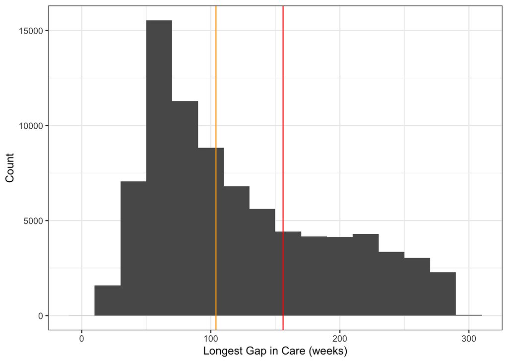

```r
# for the whole cohort what is the distribution of the longest gap in care
all_FU_w_gaps %>%
  group_by(pat_id) %>%
  filter(wks_to_next_enc == max(wks_to_next_enc, na.rm=TRUE)) %>%
  ungroup() %>%
  ggplot(data=., aes(x=wks_to_next_enc)) +
  geom_histogram(binwidth=20) +
  ylab('Count') +
  xlab('Longest Gap in Care (weeks)') +
  geom_vline(xintercept=104, color='orange') + # 2 years
  geom_vline(xintercept=156, color='red') + # 3 years
  theme_bw()
```

```r
# for each patient take their max gap and their time from the end of follow-up
ltfu_unique <- all_FU_w_gaps %>%
  ## select all gaps where a patient disengages for two years or more
  filter(wks_to_next_enc > 156 & enc_date > index_enc_date) %>%
  group_by(pat_id) %>%
  ## find the earliest date when they do this
  filter(enc_date == min(enc_date)) %>%
  ## if this date is not the same as their last
  ungroup() %>%
  mutate(ltfu_status = case_when(enc_date == most_recent_enc_date ~ 'complete',
                                 enc_date != most_recent_enc_date ~ 'partial'),
         ltfu_date = enc_date,
         ltfu_reengage_date = next_enc_date)
```

The number of patients who completely disengage at some point during follow-up (disengage three years or more before the end of follow-up) is n=20739.

The number of patients who partially disengage at some point during follow-up (disengage for three years or more but re-engage in relevant care before the end of follow-up) is n=2957.

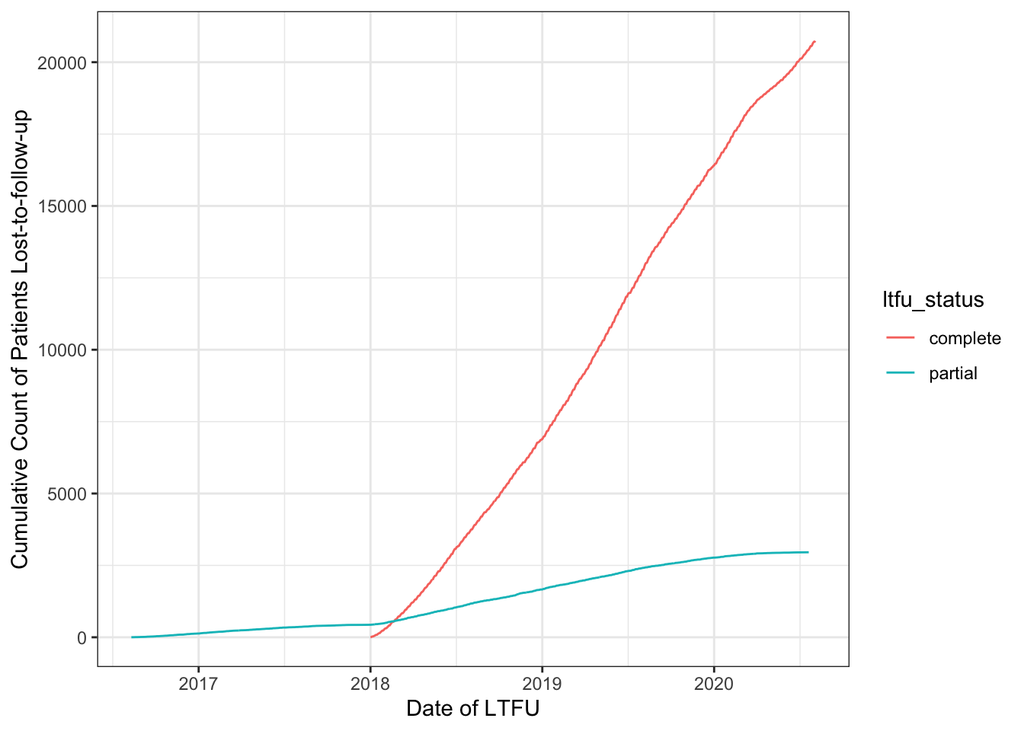

```r
ltfu_unique %>%
  group_by(ltfu_date, ltfu_status) %>%
  summarise(count=n(), .groups='drop') %>%
  group_by(ltfu_status) %>%
  mutate(cumulative_count = cumsum(count)) %>%
  ungroup() %>%
  ggplot(data=., aes(x=ltfu_date, y=cumulative_count, color=ltfu_status)) +
  geom_line() +
  ylab('Cumulative Count of Patients Lost-to-follow-up') +
  xlab('Date of LTFU') +
  theme_bw()
```

NOTE: this includes all patients regardless of other censoring and case diagnosis. A more accurate summary of LTFU will be at the end of the document.

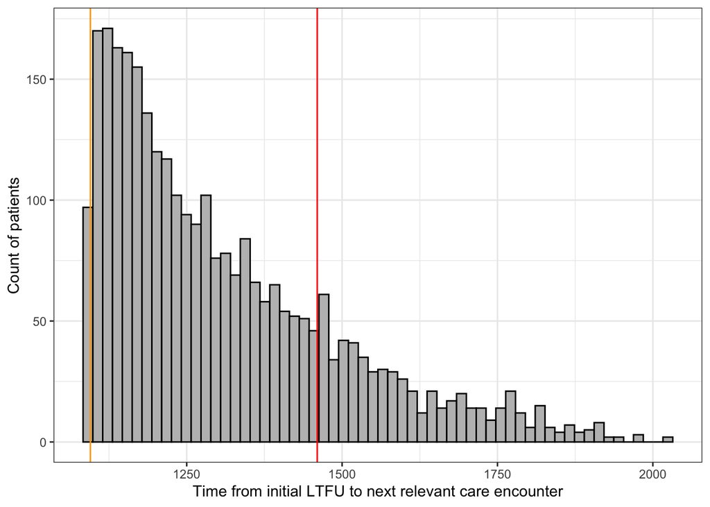

```r
# time between initial LTFU and re-engage date for partial LTFU
ltfu_unique %>%
  filter(ltfu_status=='partial') %>%
  mutate(time_to_reengage = as.numeric(difftime(ltfu_reengage_date, ltfu_date, units='day'))) %>%
  #summary()
  ggplot(data=., aes(x=time_to_reengage)) +
  geom_histogram(bins=60, fill='gray', color='black') +
  geom_vline(xintercept=365*3, color='orange') +
  geom_vline(xintercept=365*4, color='red') +
  xlab('Time from initial LTFU to next relevant care encounter') +
  ylab('Count of patients') +
  theme_bw()
```

### COVID-19 Loss to follow up

I will create separate inverse probability censoring weights for this subgroup (the former being identified as no in-person encounters from March 15, 2020-July 1, 2021 [dates of closing and reopening of NYC] but then seen again).

This will be defined as any patients whose last encounter was after COVID-19 (later than 2021-07-01) but during the lock down period they have no in-person encounters.

```r
## capture a list of patients NOT LTFU during COVID-19
covid_not_LTFU <- all_enc %>%
  # Exclude telemedicine encounters
  filter(enc_type != 'Telemedicine') %>%
  # Filter to dates of interest
  filter(enc_date >= '2020-03-15' & enc_date <= '2021-07-01') %>%
  distinct(pat_id)

pat_unique_final$ltfu_covid <- ifelse(!pat_unique_final$pat_id %in% covid_not_LTFU$pat_id & pat_unique_final$last_enc_date >= '2021-07-01', TRUE, FALSE)
```

There are 10096 with no relevant in-person encounters during the COVID-19 lock down for NYC. This is 12.3% of patients overall.

Later I will compare the demographics of these patients to other patients, to see if they may informatively be censored in the data.

## 1.3. Censoring not due to diagnosis of UF or Endo

### Death

There are 107 patient who died during the follow-up period.

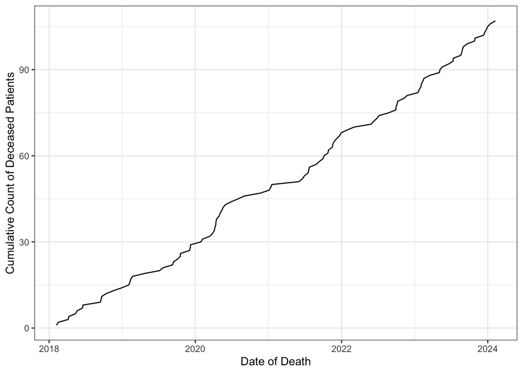

```r
pat_unique_final %>%
  filter(!is.na(death_date)) %>%
  group_by(death_date) %>%
  summarise(count=n(), .groups='drop') %>%
  mutate(cumulative_count = cumsum(count)) %>%
  ggplot(data=., aes(x=death_date, y=cumulative_count)) +
  geom_line() +
  ylab('Cumulative Count of Deceased Patients') +
  xlab('Date of Death') +
  theme_bw()
```

### Hysterectomy or bilateral oophorectomy

```r
# do I need to use codes?
cpt_codes <- c('1962', '38589', '58150', '58180', '58210', '58260',
               '58541', '58542', '58544', '58550', '58553', '58570',
               '58572', '58573', 'SHX1221', 'SHX1223', 'SHX1926', 'SHX1934',
               'SHX209', 'SHX210', 'SHX21050', 'SHX2362', 'SHX2548', 'SHX81',
               'SHX82', 'SUR292', 'SUR658', 'SUR661', 'SUR797', 'SUR800')

length(which(surgery$procedure_code %in% cpt_codes)) ## none of these show up table so ignore
```

The surgery table includes completed and scheduled surgeries so I need to remove those prior to cohort entry and after the last date of follow-up.

```r
## only focus on surgeries during follow-up
surgery_FU <- surgery %>%
  mutate(surgery_date = as.Date(surgery_date)) %>%
  filter(surgery_date > '2016-08-01' & surgery_date <= '2023-10-01')
```

```r
# mark procedure names from above
censor_surg <- surgery_FU %>%
  mutate(hysterectomy = case_when(grepl('HYSTERECTOMY', procedure_name)~TRUE),
         bilateral_oophorectomy = case_when(grepl('OOPHORECTOMY', procedure_name) &
                                    grepl('BILATERAL', procedure_name)~TRUE,
                                  grepl('OOPHORECTOMY', procedure_name) &
                                    grepl('Bilateral', laterality)~TRUE)) %>%
  filter(hysterectomy | bilateral_oophorectomy)
```

```r
# look at patient with multiple observations
censor_surg %>%
  group_by(pat_id) %>%
  filter(n()>1) %>%
  arrange(pat_id, surgery_date) %>%
  View()
```

```r
# turn into observations per patient id
censor_surg_unique <- censor_surg %>%
  filter(pat_id %in% pat_unique_final$pat_id) %>%
  group_by(pat_id, surgery_date) %>%
  mutate(hysterectomy = case_when(sum(hysterectomy, na.rm=T)>=1~TRUE),
         bilateral_oophorectomy = case_when(sum(bilateral_oophorectomy, na.rm=T)>=1~TRUE)) %>%
  ungroup() %>%
  select(pat_id, surgery_date, hysterectomy, bilateral_oophorectomy) %>%
  distinct() %>%
  group_by(pat_id) %>%
  filter(surgery_date==min(surgery_date)) %>%
  ungroup() %>%
  rename(censor_surg_date = surgery_date)
```

There are 932 patients who receive a hysterectomy or bilateral oophorectomy at some point during follow-up. 630 patients received a hysterectomy only, 95 patients received a bilateral oophorectomy only, and 207 patients received both.

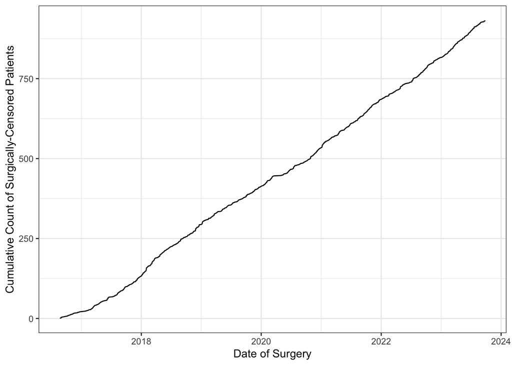

```r
censor_surg_unique %>%
  group_by(censor_surg_date) %>%
  summarise(count=n_distinct(pat_id), .groups='drop') %>%
  mutate(cumulative_count = cumsum(count)) %>%
  ggplot(data=., aes(x=censor_surg_date, y=cumulative_count, label=cumulative_count)) +
  geom_line() +
  ylab('Cumulative Count of Surgically-Censored Patients') +
  xlab('Date of Surgery') +
  theme_bw()
```

**NEXT STEP**: Some of these are very close to entry into cohort – if so they will be censored very early, should they be excluded similar to not getting relevant care in the year following entry into cohort? I guess if they did not receive a diagnosis during this time prior to surgery then they just received the procedure for some other reason which is fine.

### Menopause (aging out)

```r
menopause_unique <- menopause %>%
  group_by(pat_id) %>%
  filter(dx_date == min(dx_date)) %>%
  arrange(pat_id, dx_date) %>%
  mutate(menopause_date = as.Date(dx_date, '%Y-%m-%d')) %>%
  distinct(pat_id, menopause_date)
```

The total number of patients who have any menopause diagnosis (and therefore would be censored at this point) is n=5209.

```r
age_out <- pat_unique_final %>%
  select(pat_id, age_20160801) %>%
  mutate(ageout_date = as.Date('2016-08-01') %m+% years(55-age_20160801)) %>%
  mutate(ageout_date = case_when(ageout_date > '2023-10-01'~NA,
                                 TRUE~ageout_date))
```

The total number of patients who age out of the cohort during follow-up (55 or older) is n=6141.

## Baseline covariates available in this data

### Healthcare Utilization at baseline and throughout follow-up

```r
hcu <- all_enc %>%
  filter(enc_date > index_enc_date & enc_date <= '2017-12-31') %>%
  group_by(pat_id) %>%
  summarise(hcu_baseline = n_distinct(pat_enc_csn_id), .groups='drop')
```

```r
hcu <- all_enc %>%
  filter(enc_date > index_enc_date & enc_date <= '2023-08-01') %>% # until end of follow-up
  mutate(enc_year = year(enc_date)) %>%
  group_by(pat_id, enc_year) %>%
  summarise(hcu_per_year = n_distinct(pat_enc_csn_id), .groups='drop') %>%
  group_by(pat_id) %>%
  summarise(hcu_fu = mean(hcu_per_year), .groups='drop') %>%
  full_join(hcu, by='pat_id') %>%
  mutate(hcu_baseline = ifelse(is.na(hcu_baseline), 0, hcu_baseline))
```

```r
print(CreateTableOne(data=hcu, vars=c('hcu_baseline', 'hcu_fu')), nonnormal = c('hcu_baseline', 'hcu_fu'))
```

```
##
##                               Overall
##   n                           123803
##   hcu_baseline (median [IQR])   1.00 [0.00, 3.00]
##   hcu_fu (median [IQR])         2.00 [1.20, 3.00]
```

### Site

The goal here is to know out of Tisch, Brooklyn, FHC and Long Island, which site is the most popular for a given patient. Despite this, most patients will predominantly seek care at outpatient clinics, but we are interested in which hospital would service them if they are to go to a hospital. Therefore as long as they have any visits to a hospital site, we will use this as their most common site. If all of their visits were to outpatient clinis, then they will be assigned ‘OTHER’.

NOTE: this is currently only for relevant encounters but we could expand to all encounters if requested.

```r
## grab most common site even if its other
site_all <- all_enc %>%
  filter(pat_id %in% pat_unique_final$pat_id) %>%
  mutate(group = ifelse(enc_date <= '2019-12-31', 'baseline', 'follow-up')) %>%
  count(pat_id, group, loc_name) %>%
  group_by(pat_id, group) %>%
  slice(which.max(n)) %>%
  ungroup()

## grab most common excluding other
site <- all_enc %>%
  filter(pat_id %in% pat_unique_final$pat_id) %>%
  filter(loc_name != 'OTHER') %>%
  mutate(group = ifelse(enc_date <= '2019-12-31', 'baseline', 'follow-up')) %>%
  count(pat_id, group, loc_name) %>%
  group_by(pat_id, group) %>%
  slice(which.max(n)) %>%
  ungroup()

# for those missing a site (likely because its other) allow it to be other (but priority is for a site if it exists)
site <- site %>%
  ## join for missing baseline
  bind_rows(site_all %>% filter(!pat_id %in% site$pat_id[which(site$group == 'baseline')] & group == 'baseline')) %>%
  ## join for missing follow-up
  bind_rows(site_all %>% filter(!pat_id %in% site$pat_id[which(site$group == 'follow-up')] & group == 'follow-up')) %>%
  # regroup LI community hospital with LI
  mutate(loc_name = ifelse(loc_name == 'LONG ISLAND COMMUNITY HOSPITAL', 'NYU LANGONE HOSPITAL - LONG ISLAND', loc_name))
```

```r
CreateTableOne(data=site, vars='loc_name', strata='group', includeNA=TRUE)
```

```
##                                        Stratified by group
##                                         baseline      follow-up     p      test
##   n                                     82062         65681
##   loc_name (%)                                                      <0.001
##      FAMILY HEALTH CENTERS              13759 (16.8)  10037 (15.3)
##      NYU LANGONE BROOKLYN                7951 ( 9.7)   6283 ( 9.6)
##      NYU LANGONE HOSPITAL - LONG ISLAND  1553 ( 1.9)   2666 ( 4.1)
##      OTHER                              36597 (44.6)  15893 (24.2)
##      TELEMEDICINE                         705 ( 0.9)  19949 (30.4)
##      TISCH HOSPITAL                     21497 (26.2)  10853 (16.5)
```

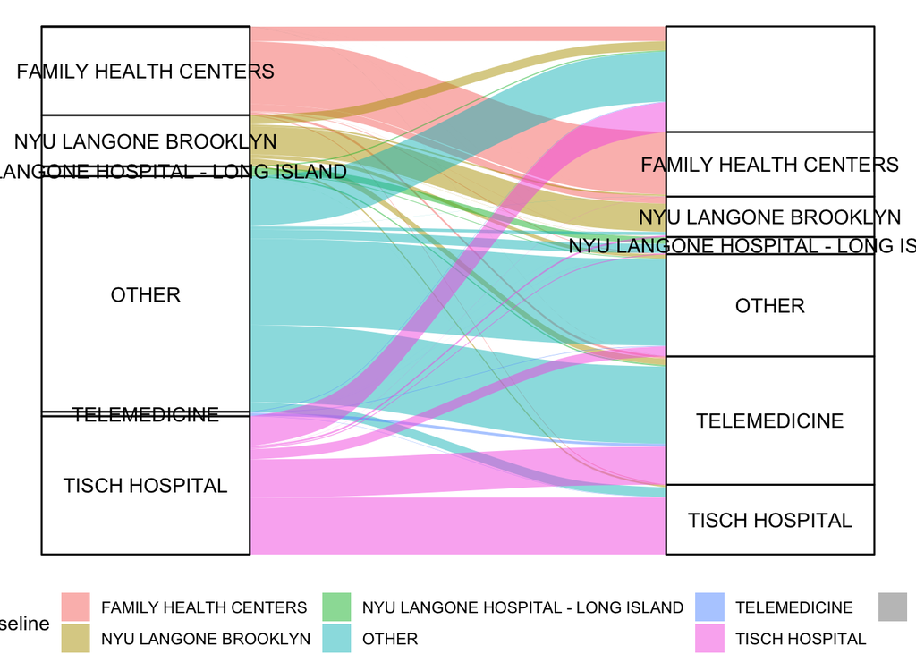

```r
site %>%
  select(-n) %>%
  pivot_wider(names_from = group, values_from = loc_name) %>%
  count(baseline, `follow-up`) %>%
  mutate(percent = (n/dim(pat_unique_final)[1])*100) %>%
  arrange(baseline, desc(percent)) %>%
  ggplot(data = .,
       aes(axis1 = baseline,   # First variable on the X-axis
           axis2 = `follow-up`, # Second variable on the X-axis
           y = percent)) +
  geom_alluvium(aes(fill = baseline)) +
  geom_stratum() +
  geom_text(stat = "stratum", aes(label = after_stat(stratum))) +
  theme_void() +
  theme(legend.position = 'bottom')
```

## Join together all dates of potential censoring/LTFU

```r
pat_unique_final <- pat_unique_final %>%
  left_join(ltfu_unique %>% select(pat_id, contains('ltfu')), by='pat_id') %>%
  left_join(censor_surg_unique %>% select(pat_id, censor_surg_date), by='pat_id') %>%
  left_join(menopause_unique, by='pat_id') %>%
  left_join(age_out %>% select(pat_id, ageout_date), by='pat_id') %>%
  left_join(hcu, by='pat_id') %>%
  left_join(site %>% select(-n) %>% pivot_wider(names_from = group, values_from=loc_name), by='pat_id')
```

```r
# create final censoring variables
pat_unique_final <- pat_unique_final %>%
  mutate(final_censor_date = pmin(as.Date(death_date), ltfu_date, censor_surg_date, menopause_date, ageout_date, na.rm = TRUE)) %>%
  mutate(final_censor_type = case_when(final_censor_date == as.Date(death_date)~'Death',
                                       final_censor_date == censor_surg_date~'Surgery',
                                       final_censor_date == menopause_date~'Menopause',
                                       final_censor_date == ageout_date~'Aged out',
                                       final_censor_date == ltfu_date &
                                         ltfu_status == 'complete'~'LTFU',
                                       TRUE~NA))
```

Distribution of first censoring event in entire cohort: (excluding due to disease diagnosis)

```r
pat_unique_final %>%
  filter(!is.na(final_censor_type)) %>%
  CreateTableOne(data=., vars='final_censor_type')
```

```
##
##                         Overall
##   n                     28507
##   final_censor_type (%)
##      Aged out            3985 (14.0)
##      Death                 44 ( 0.2)
##      LTFU               20426 (71.7)
##      Menopause           3182 (11.2)
##      Surgery              870 ( 3.1)
```

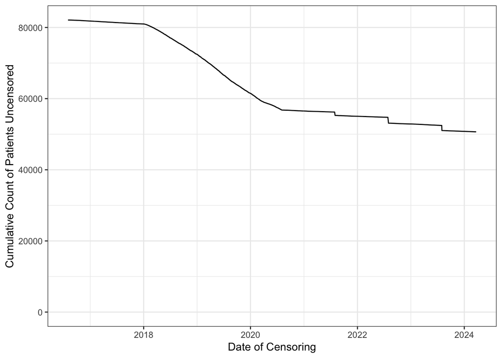

```r
n_total <- length(unique(pat_unique_final$pat_id))

pat_unique_final %>%
  group_by(final_censor_date) %>%
  summarise(count=n(), .groups='drop') %>%
  mutate(cumulative_count = n_total - cumsum(count)) %>%
  ggplot(data=., aes(x=final_censor_date, y=cumulative_count)) +
  geom_line() +
  ylab('Cumulative Count of Patients Uncensored') +
  xlab('Date of Censoring') +
  theme_bw()
```

```r
## add mrn to the file
pat_unique_final <- pat_unique_final %>%
  left_join(pat_cohort %>%
              filter(pat_id %in% pat_unique_final$pat_id) %>%
              distinct(pat_id, pat_mrn_id), by = 'pat_id')

## write out file with date and reason for LTFU or censoring during follow-up for all patients
write.csv(pat_unique_final, 'Data/Derived/pat_cohort_w_censoring.csv', row.names=FALSE)
## some may be retrospectively overwritten if they are diagnosed with UF or Endo before that point
```